# Vaccination Rate Mini-Project: class17

# Focus on UCSD/La Jolla

UC San Diego resides in the 92037 ZIP code area and is listed with an age 5+ population size of 36,144.

```r
ucsd <- filter(sd, zip_code_tabulation_area=="92037")
ucsd[1,]$age5_plus_population
```

```
## [1] 36144
```

**Q15**. Using ggplot make a graph of the vaccination rate time course for the 92037 ZIP code area:

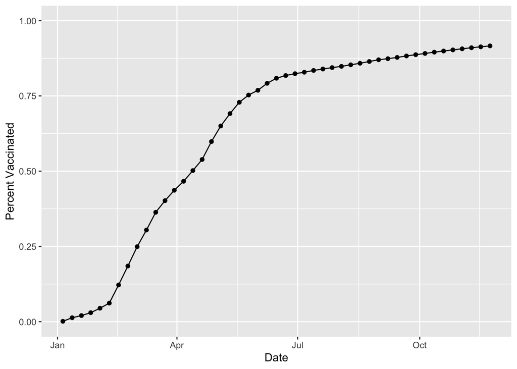

```r
library(ggplot2)
ggplot(ucsd) +
  aes(as_of_date,
      percent_of_population_fully_vaccinated) +
  geom_point() +
  geom_line(group=1) +
  ylim(c(0,1)) +
  labs(x="Date", y="Percent Vaccinated")
```

This plot shows an initial slow roll out in January into Febuary (likely due to limited vaccine availability). This is followed with rapid ramp up until a clear slowing trend from June time onward. Interpertation beyond this requies context from other zip code areas to answer questions such as: is this trend representative of other areas? Are more people fully vaccinated in this area compared to others? Etc.

# Comparing to similar sized areas

Let’s return to the full dataset and look across every zip code area with a population at least as large as that of 92037 on as_of_date “2021-11-16”.

```r
# Subset to all CA areas with a population as large as 92037
vax.36 <- filter(vax, age5_plus_population > 36144 &
                as_of_date == "2021-11-16")
head(vax.36)
```

```
##   as_of_date zip_code_tabulation_area local_health_jurisdiction         county
## 1 2021-11-16                    92020                 San Diego      San Diego
## 2 2021-11-16                    92563                 Riverside      Riverside
## 3 2021-11-16                    92806                    Orange         Orange
## 4 2021-11-16                    93291                    Tulare         Tulare
## 5 2021-11-16                    92335            San Bernardino San Bernardino
## 6 2021-11-16                    92618                    Orange         Orange
##   vaccine_equity_metric_quartile                 vem_source
## 1                              2 Healthy Places Index Score
## 2                              3 Healthy Places Index Score
## 3                              2 Healthy Places Index Score
## 4                              1 Healthy Places Index Score
## 5                              1 Healthy Places Index Score
## 6                              4 Healthy Places Index Score
##   age12_plus_population age5_plus_population persons_fully_vaccinated
```

[output cut: 27 more lines]

**Q16**. Calculate the mean “Percent of Population Fully Vaccinated” for ZIP code areas with a population as large as 92037 (La Jolla) as_of_date “2021-11-16”. Add this as a straight horizontal line to your plot from above with the geom_hline() function?

```r
mean(vax.36$percent_of_population_fully_vaccinated)
```

```
## [1] 0.6640413
```

Let’s make a new plot:

```r
ucsd$as_of_date
```

```
##  [1] "2021-01-05" "2021-01-12" "2021-01-19" "2021-01-26" "2021-02-02"
##  [6] "2021-02-09" "2021-02-16" "2021-02-23" "2021-03-02" "2021-03-09"
## [11] "2021-03-16" "2021-03-23" "2021-03-30" "2021-04-06" "2021-04-13"
## [16] "2021-04-20" "2021-04-27" "2021-05-04" "2021-05-11" "2021-05-18"
## [21] "2021-05-25" "2021-06-01" "2021-06-08" "2021-06-15" "2021-06-22"
## [26] "2021-06-29" "2021-07-06" "2021-07-13" "2021-07-20" "2021-07-27"
## [31] "2021-08-03" "2021-08-10" "2021-08-17" "2021-08-24" "2021-08-31"
## [36] "2021-09-07" "2021-09-14" "2021-09-21" "2021-09-28" "2021-10-05"
## [41] "2021-10-12" "2021-10-19" "2021-10-26" "2021-11-02" "2021-11-09"
## [46] "2021-11-16" "2021-11-23"
```

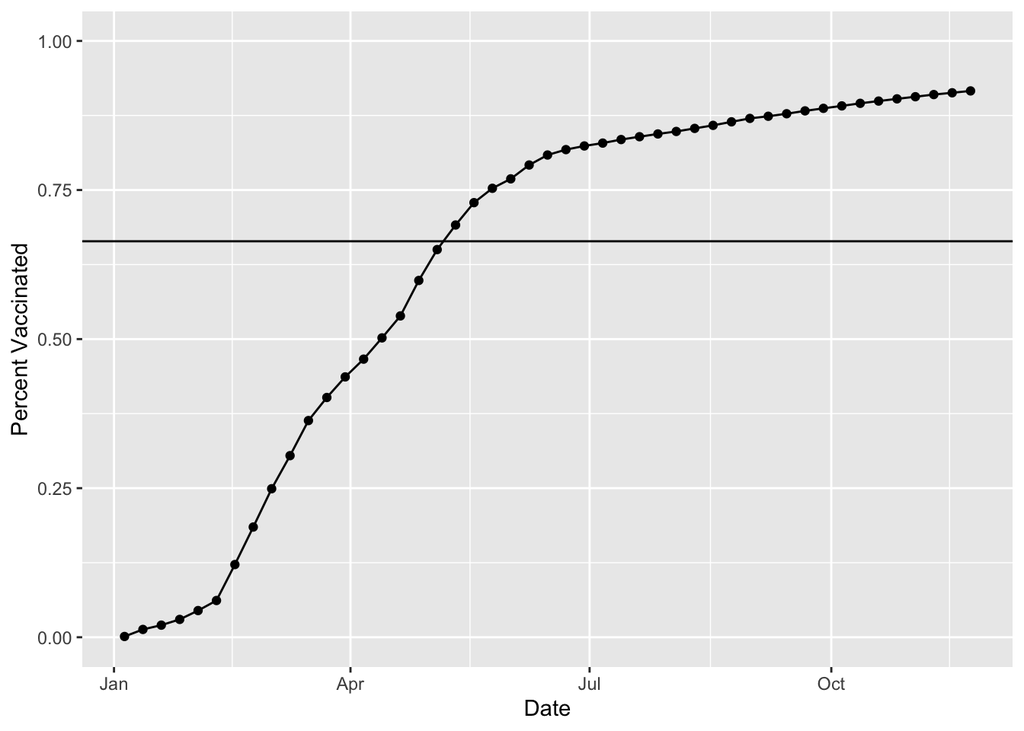

```r
ggplot(ucsd) +
  aes(as_of_date,
  percent_of_population_fully_vaccinated) +
  geom_point() +
  geom_line(group=1) +
  ylim(c(0,1)) +
  labs(x="Date", y="Percent Vaccinated") +
  geom_hline(yintercept = 0.6640413)
```

**Q17**. What is the 6 number summary (Min, 1st Qu., Median, Mean, 3rd Qu., and Max) of the “Percent of Population Fully Vaccinated” values for ZIP code areas with a population as large as 92037 (La Jolla) as_of_date “2021-11-16”?

```r
dat <- summary(vax.36$percent_of_population_fully_vaccinated)
head(dat)
```

```
##      Min.   1st Qu.    Median      Mean   3rd Qu.      Max.
## 0.3528910 0.5905170 0.6661630 0.6640413 0.7297545 1.0000000
```

**Q18**. Using `ggplot`, generate a histogram of this data.

```r
vax.36$percent_of_population_fully_vaccinated
```

```
##   [1] 0.638795 0.565116 0.675304 0.514911 0.542306 0.895969 0.610183 0.754831
##   [9] 0.671440 0.685062 0.571825 0.685009 0.789706 0.758088 0.758018 0.668217
##  [17] 0.533796 0.651510 0.687135 0.672017 0.705095 0.765967 0.544121 0.829537
##  [25] 0.637903 0.700493 0.613925 0.628329 0.642227 0.654824 0.631281 0.682419
##  [33] 0.819272 0.730465 0.573062 0.875929 0.659628 0.511820 0.706522 0.671575
##  [41] 0.709131 0.526173 0.721366 0.821927 0.556778 0.536308 0.512772 0.674613
##  [49] 0.690915 0.589145 0.661266 0.818517 0.703561 0.556520 0.756571 0.867086
##  [57] 0.556596 0.698836 0.636051 0.777597 0.625551 0.631382 0.716066 0.588702
##  [65] 0.539396 0.707375 0.718392 0.472181 0.528009 0.796706 0.644050 0.783687
##  [73] 0.631097 0.956078 0.753598 0.547531 0.597529 0.480697 0.618461 0.688234
##  [81] 0.610172 0.881642 0.836037 0.649573 0.565566 0.532163 0.795321 0.687544
##  [89] 0.671494 0.542527 0.548829 0.573898 0.687350 0.878852 0.666937 0.841436
##  [97] 0.637505 0.562748 0.677776 0.700007 0.572831 0.606870 0.553326 0.714489
## [105] 0.537228 0.750175 0.563423 0.745997 0.643037 0.749612 0.623749 0.680768
## [113] 0.767511 0.521701 0.522434 0.682254 0.523732 0.583474 0.653602 0.741917
```

[output cut: 37 more lines]

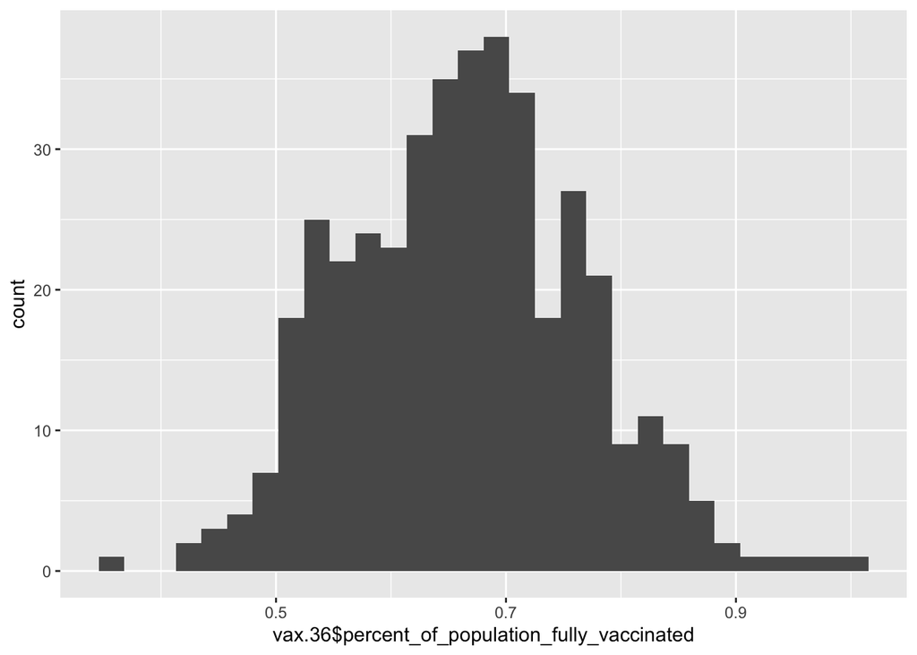

```r
ggplot(vax.36) +
  aes(vax.36$percent_of_population_fully_vaccinated) +
  geom_histogram()
```

**Q19**. Is the 92109 and 92040 ZIP code areas above or below the average value you calculated for all these above?

```r
vax %>% filter(as_of_date == "2021-11-16") %>%
  filter(zip_code_tabulation_area=="92040") %>%
  select(percent_of_population_fully_vaccinated)
```

```
##   percent_of_population_fully_vaccinated
## 1                               0.521047
```

```r
vax %>% filter(as_of_date == "2021-11-16") %>%
  filter(zip_code_tabulation_area=="92109") %>%
  select(percent_of_population_fully_vaccinated)
```

```
##   percent_of_population_fully_vaccinated
## 1                                0.68863
```

–> 92109 ZIP code = above, 92040 ZIP code = below

**Q20**. Finally, make a time course plot of vaccination progress for all areas in the full dataset with a age5_plus_population > 36144.

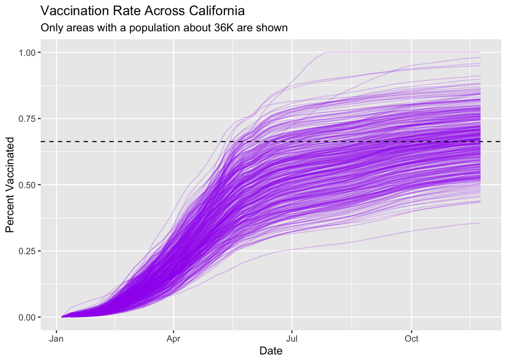

```r
vax.36.all <- filter(vax, age5_plus_population > 36144)
ggplot(vax.36.all) +
  aes(as_of_date,
      percent_of_population_fully_vaccinated,
      group=zip_code_tabulation_area) +
  geom_line(alpha=0.2, color="purple") +
  ylim(c(0,1)) +
  labs(x="Date", y="Percent Vaccinated",
       title="Vaccination Rate Across California",
       subtitle="Only areas with a population about 36K are shown") +
  geom_hline(yintercept = 0.6629812, linetype = "dashed")
```

**Q21**. How do you feel about traveling for Thanksgiving and meeting for in-person class next week?

–> I missed our in-person class this week due to travel plans, but was able to work through the mini-project :)